# BC2S2 vs BC2S3 — which generation do the bulked skim genotypes reflect?

Author

Fausto Rodríguez-Zapata

Published

June 26, 2026

**Repo:** sawers-rellan-labs/zealtiger

## The question

The SNP50K skim genotypes are **not single BC2S3 plants**. Each “line” was genotyped from a **bulk of 6 individual S3 plants sampled from one S2 ear** (the `.B`-suffixed *bulked genotypes*). Pooling 6 S3 sibs averages out their individual S2→S3 recombination and Mendelian segregation, so the bulk **recovers the genotype of the shared S2 parent** — these are **S2:3 lines**, and the genotype expectations to compare against are the **BC2S2** generation, not BC2S3. (Established with R. Rellán-Álvarez and J. Holland, Nov 2025.)

This document tests that interpretation two independent ways, **assuming the current ancestry calls are good enough**:

1. **Genomic proportions** — does the genome-wide REF/HET/ALT composition match the single-locus model at **BC2S2** better than at BC2S3? (The discriminator is **heterozygosity**.)
2. **Fragment size** — does the donor-segment-size distribution match the **BC2S2** expectation (one fewer meiosis → slightly longer blocks) better than BC2S3?

The two tests probe different things: (1) depends on *composition* (and is sensitive to selection on donor content), while (2) depends on *recombination* (set by the number of meioses, and is selection-independent). Agreement between them is the robustness check.

```r
library(tidyverse); library(simcross); library(furrr); library(patchwork)
purrr::walk(fs::dir_ls("R", glob = "*.R"), source)
theme_set(theme_bw())

anchors  <- readRDS(params$map)
chr_cm   <- anchors %>% group_by(chr) %>% summarise(L = max(cm), .groups = "drop") %>% arrange(chr)
ped      <- bc2s3_pedigree()          # id7 = S2 (BC2S2), id8 = S3 (BC2S3)
mp       <- anchors %>% group_by(chr, bp) %>% summarise(cm = mean(cm), .groups = "drop")
mb2cm    <- function(chr, bp) {        # forward consensus-map lookup, clamp past last anchor
  o <- numeric(length(bp))
  for (cc in unique(chr)) { i <- chr == cc; a <- mp %>% filter(chr == cc) %>% arrange(bp)
    o[i] <- approx(a$bp, a$cm, xout = bp[i], rule = 2)$y }
  o
}
```

## The single-locus model

With no selection the donor *dosage* (allele frequency) stays at 0.125 from BC2 onward, so it **cannot** distinguish generations. What changes under selfing is the split between heterozygous and homozygous-donor: **heterozygosity halves each selfing generation**. That makes HET the discriminator.

```r
h <- 0.25; a <- 0; rows <- list()
for (g in c("BC2 (S0)","BC2S1","BC2S2","BC2S3","BC2S4")) {
  rows[[g]] <- tibble(generation = g, REF = 1 - h - a, HET = h, ALT_hom = a, dosage = h/2 + a)
  hn <- h/2; a <- a + h/4; h <- hn
}
single_locus <- bind_rows(rows)
knitr::kable(single_locus %>% mutate(across(where(is.numeric), ~round(., 4))),
  caption = "Single-locus genotype frequencies (no selection). BC2S2 HET = 0.0625 vs BC2S3 = 0.0312 — the 2× difference is the generation discriminator.")
```

Single-locus genotype frequencies (no selection). BC2S2 HET = 0.0625 vs BC2S3 = 0.0312 — the 2× difference is the generation discriminator.

| generation | REF | HET | ALT_hom | dosage |
| --- | --- | --- | --- | --- |
| BC2 (S0) | 0.7500 | 0.2500 | 0.0000 | 0.125 |
| BC2S1 | 0.8125 | 0.1250 | 0.0625 | 0.125 |
| BC2S2 | 0.8438 | 0.0625 | 0.0938 | 0.125 |
| BC2S3 | 0.8594 | 0.0312 | 0.1094 | 0.125 |
| BC2S4 | 0.8672 | 0.0156 | 0.1172 | 0.125 |

```r
exp_bc2s2 <- single_locus %>% filter(generation == "BC2S2")
exp_bc2s3 <- single_locus %>% filter(generation == "BC2S3")
```

## Analysis 1 — genomic proportions

Genome-wide fraction in each state (REF / HET / ALT-homozygous), per skim sample, then averaged.

```r
sk <- read_csv(params$skim_calls, show_col_types = FALSE)
sf <- sk %>% mutate(len = end_bp - start_bp) %>% group_by(name) %>%
  summarise(HET = sum(len[state == 1]) / sum(len),
            ALT = sum(len[state == 2]) / sum(len), .groups = "drop") %>%
  mutate(dosage = HET/2 + ALT)

obs_tbl <- tibble(
  source = c("Observed skim (mean)", "BC2S2 expectation", "BC2S3 expectation"),
  n      = c(nrow(sf), NA, NA),
  HET    = c(mean(sf$HET), exp_bc2s2$HET, exp_bc2s3$HET),
  ALT_hom= c(mean(sf$ALT), exp_bc2s2$ALT_hom, exp_bc2s3$ALT_hom),
  dosage = c(mean(sf$dosage), exp_bc2s2$dosage, exp_bc2s3$dosage))
knitr::kable(obs_tbl %>% mutate(across(c(HET, ALT_hom, dosage), ~round(., 4))),
  caption = sprintf("Observed skim genome composition (%d samples) vs the single-locus expectations. Observed HET %.4f (median %.4f).",
                    nrow(sf), mean(sf$HET), median(sf$HET)))
```

Observed skim genome composition (1393 samples) vs the single-locus expectations. Observed HET 0.0755 (median 0.0654).

| source | n | HET | ALT_hom | dosage |
| --- | --- | --- | --- | --- |
| Observed skim (mean) | 1393 | 0.0755 | 0.0345 | 0.0722 |
| BC2S2 expectation | NA | 0.0625 | 0.0938 | 0.1250 |
| BC2S3 expectation | NA | 0.0312 | 0.1094 | 0.1250 |

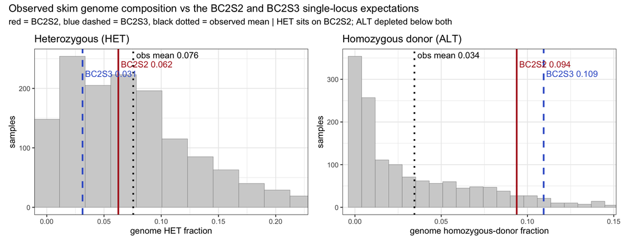

```r
frac_panel <- function(col, e2, e3, xlab, title) {
  m <- mean(sf[[col]])
  ggplot(sf, aes(.data[[col]])) +
    geom_histogram(bins = 40, fill = "grey82", colour = "grey55", linewidth = 0.2) +
    geom_vline(xintercept = e2, colour = "firebrick",  linewidth = 1) +
    geom_vline(xintercept = e3, colour = "royalblue3", linewidth = 1, linetype = "dashed") +
    geom_vline(xintercept = m,  colour = "black",      linewidth = 1, linetype = "dotted") +
    annotate("text", x = m,  y = Inf, label = sprintf("obs mean %.3f", m), colour = "black",      hjust = -0.05, vjust = 1.5) +
    annotate("text", x = e2, y = Inf, label = sprintf("BC2S2 %.3f", e2),   colour = "firebrick",  hjust = -0.05, vjust = 3.0) +
    annotate("text", x = e3, y = Inf, label = sprintf("BC2S3 %.3f", e3),   colour = "royalblue3", hjust = -0.05, vjust = 4.5) +
    coord_cartesian(xlim = c(0, max(quantile(sf[[col]], 0.98), e3 + 0.02))) +
    labs(x = xlab, y = "samples", title = title)
}
p_het <- frac_panel("HET", exp_bc2s2$HET,     exp_bc2s3$HET,     "genome HET fraction",              "Heterozygous (HET)")
p_alt <- frac_panel("ALT", exp_bc2s2$ALT_hom, exp_bc2s3$ALT_hom, "genome homozygous-donor fraction",  "Homozygous donor (ALT)")
(p_het | p_alt) +
  plot_annotation(
    title = "Observed skim genome composition vs the BC2S2 and BC2S3 single-locus expectations",
    subtitle = "red = BC2S2, blue dashed = BC2S3, black dotted = observed mean | HET sits on BC2S2; ALT depleted below both")
```

**Read.** Observed HET (mean 0.076, median 0.065) sits on the **BC2S2** value (0.0625) and far from BC2S3 (0.0312) — consistent with the 6-plant bulk recovering the S2 parent. Two confounds sit *on top* of the generation signal and do not change the call:

- **Total donor dosage is 0.072, well below the model’s 0.125** → directional **selection against donor** (temperate-adaptation selection purging teosinte alleles). The homozygous-donor plot above shows this directly: observed ALT (mean 0.034) sits well *left* of both generations’ expectations (BC2S2 0.094, BC2S3 0.109) — so the depletion falls on the homozygous-donor class, while HET is retained at the BC2S2 level.
- **HET:ALT ≈ 2.2:1, vs BC2S2’s 0.67:1** → **het excess** (overdominance / heterozygote-biased retention) beyond any neutral selfing generation. (B73/Purple check samples, included here, only *lower* HET, so they make this a conservative test of the BC2S2 call.)

## The BC2S2 / BC2S3 fragment expectation (paired simulation)

Simulate donor segments for **both** the S2 parent (`id7`) and its S3 self (`id8`) from the *same* pedigree realizations (`simcross`, Stahl m=10/p=0), so the only difference is **one extra meiosis** in BC2S3. Segments are the union of donor intervals over both haplotypes, converted to Mb through the consensus map.

```r
n <- 1500L; set.seed(20260609); plan(multisession)
segs_for <- function(sim, id) purrr::map_dfr(seq_along(chr_cm$L), function(ci) {
  hs <- donor_segments_cm(sim[[ci]][[id]], donor_allele = 2L)
  u  <- union_intervals(hs$start_cm, hs$end_cm)
  if (nrow(u) == 0) return(tibble(chr = integer(0), start_cm = numeric(0), end_cm = numeric(0)))
  tibble(chr = chr_cm$chr[ci], start_cm = u$start, end_cm = u$end)
})
res <- furrr::future_map(seq_len(n), function(i) {
  sim <- simcross::sim_from_pedigree(ped, L = chr_cm$L, m = 10, p = 0)
  list(s2 = segs_for(sim, "7") %>% mutate(nil_id = i),
       s3 = segs_for(sim, "8") %>% mutate(nil_id = i))
}, .options = furrr_options(seed = TRUE))
to_mb <- function(cm) segments_to_mb(dplyr::select(cm, nil_id, chr, start_cm, end_cm), anchors) %>%
  mutate(cm = end_cm - start_cm)
sim_s2 <- to_mb(map_dfr(res, "s2")); sim_s3 <- to_mb(map_dfr(res, "s3"))
```

```r
gfit <- function(x) { f <- suppressWarnings(MASS::fitdistr(x/100, "gamma")$estimate)
  sprintf("Gamma(k=%.2f, λ=%.2f/M)", f["shape"], f["rate"]) }
knitr::kable(tibble(
  generation = c("BC2S2 (g=4 meioses)", "BC2S3 (g=5 meioses)"),
  n_segments = c(nrow(sim_s2), nrow(sim_s3)),
  median_cM  = round(c(median(sim_s2$cm),  median(sim_s3$cm)), 1),
  mean_cM    = round(c(mean(sim_s2$cm),    mean(sim_s3$cm)), 1),
  median_Mb  = round(c(median(sim_s2$mb),  median(sim_s3$mb)), 1),
  cM_law     = c(gfit(sim_s2$cm), gfit(sim_s3$cm))),
  caption = "Paired fragment-size expectations. BC2S2 blocks are modestly longer (one fewer meiosis).")
```

Paired fragment-size expectations. BC2S2 blocks are modestly longer (one fewer meiosis).

| generation | n_segments | median_cM | mean_cM | median_Mb | cM_law |
| --- | --- | --- | --- | --- | --- |
| BC2S2 (g=4 meioses) | 15567 | 21.5 | 26.8 | 12.4 | Gamma(k=1.20, λ=4.48/M) |
| BC2S3 (g=5 meioses) | 15286 | 19.4 | 24.6 | 11.1 | Gamma(k=1.16, λ=4.72/M) |

## Analysis 2 — fragment size

Observed skim donor blocks (maximal runs of donor state), in both cM (forward map lookup) and Mb, vs each generation’s simulated distribution (KS).

```r
obs <- sk %>% arrange(name, chr, start_bp) %>% group_by(name, chr) %>%
  mutate(run = cumsum(c(TRUE, diff(state > 0) != 0)), donor = state > 0) %>% filter(donor) %>%
  group_by(name, chr, run) %>% summarise(s = min(start_bp), e = max(end_bp), .groups = "drop") %>%
  mutate(cm = mb2cm(chr, e) - mb2cm(chr, s), mb = (e - s)/1e6) %>% filter(cm > 0)

ks_tbl <- tibble(
  reference        = c("BC2S2 (g=4)", "BC2S3 (g=5)"),
  median_cM        = round(c(median(sim_s2$cm), median(sim_s3$cm)), 1),
  `KS cM`          = round(c(suppressWarnings(ks.test(obs$cm, sim_s2$cm)$statistic),
                             suppressWarnings(ks.test(obs$cm, sim_s3$cm)$statistic)), 3),
  `KS Mb`          = round(c(suppressWarnings(ks.test(obs$mb, sim_s2$mb)$statistic),
                             suppressWarnings(ks.test(obs$mb, sim_s3$mb)$statistic)), 3))
knitr::kable(ks_tbl, caption = sprintf(
  "Observed skim donor blocks (n=%d; median %.1f cM / %.1f Mb) vs each generation. Lower KS = better fit.",
  nrow(obs), median(obs$cm), median(obs$mb)))
```

Observed skim donor blocks (n=8136; median 25.4 cM / 17.3 Mb) vs each generation. Lower KS = better fit.

| reference | median_cM | KS cM | KS Mb |
| --- | --- | --- | --- |
| BC2S2 (g=4) | 21.5 | 0.090 | 0.090 |
| BC2S3 (g=5) | 19.4 | 0.117 | 0.114 |

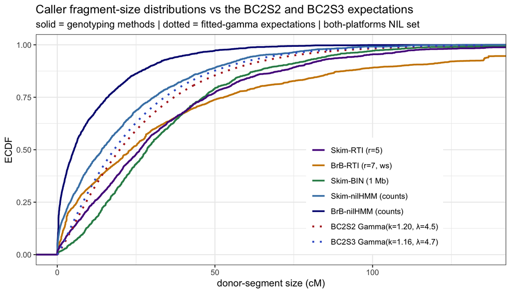

```r
# --- the 3 genotyping methods (cM segments) on the both-platforms NIL set (cf. fragment_size_cm_validation) ---
brb     <- read_csv(params$brb_taxa, show_col_types = FALSE)
skimbin <- read_csv(params$skimbin,  show_col_types = FALSE)
nilhmm  <- read_csv(params$nilhmm,   show_col_types = FALSE)   # Skim-nilHMM count-HMM, same skim reads
brbnil  <- read_csv(params$brbnil,   show_col_types = FALSE)   # BrB-nilHMM count-HMM, same BRB reads as BrB-RTI (keyed on BRB name)
corr    <- read_csv(params$corr, show_col_types = FALSE) %>% filter(type == "NIL")
brb_in  <- corr %>% separate_rows(brbseq_prefix, sep = ";") %>% transmute(name = brbseq_prefix, nil = pedigree) %>% filter(name %in% brb$name)
skim_in <- corr %>% separate_rows(skim_prefix,  sep = ";") %>% transmute(name = skim_prefix,  nil = pedigree) %>% filter(name %in% sk$name)
both_nils <- intersect(brb_in$nil, skim_in$nil)
blocks_cm <- function(seg) seg %>% arrange(name, chr, start_bp) %>% group_by(name, chr) %>%
  mutate(run = cumsum(c(TRUE, diff(state > 0) != 0)), donor = state > 0) %>% filter(donor) %>%
  group_by(name, chr, run) %>% summarise(s = min(start_bp), e = max(end_bp), .groups = "drop") %>%
  mutate(cm = mb2cm(chr, e) - mb2cm(chr, s)) %>% filter(cm > 0)
callers <- bind_rows(
  blocks_cm(sk      %>% filter(name %in% skim_in$name[skim_in$nil %in% both_nils])) %>% mutate(src = "Skim-RTI (r=5)"),
  blocks_cm(brb     %>% filter(name %in% brb_in$name [brb_in$nil  %in% both_nils])) %>% mutate(src = "BrB-RTI (r=7, ws)"),
  blocks_cm(skimbin %>% filter(name %in% skim_in$name[skim_in$nil %in% both_nils])) %>% mutate(src = "Skim-BIN (1 Mb)"),
  blocks_cm(nilhmm  %>% filter(name %in% skim_in$name[skim_in$nil %in% both_nils])) %>% mutate(src = "Skim-nilHMM (counts)"),
  blocks_cm(brbnil  %>% filter(name %in% brb_in$name [brb_in$nil  %in% both_nils])) %>% mutate(src = "BrB-nilHMM (counts)"))

# --- fitted gamma over each simulation = the BC2S2 / BC2S3 expectations (dotted) ---
f2 <- suppressWarnings(MASS::fitdistr(sim_s2$cm/100, "gamma")$estimate)
f3 <- suppressWarnings(MASS::fitdistr(sim_s3$cm/100, "gamma")$estimate)
lab2 <- sprintf("BC2S2 Gamma(k=%.2f, λ=%.1f)", f2["shape"], f2["rate"])
lab3 <- sprintf("BC2S3 Gamma(k=%.2f, λ=%.1f)", f3["shape"], f3["rate"])
xs <- seq(0, quantile(callers$cm, 0.98), length.out = 400)
gammas <- bind_rows(
  tibble(cm = xs, F = pgamma(xs/100, f2["shape"], f2["rate"]), expectation = lab2),
  tibble(cm = xs, F = pgamma(xs/100, f3["shape"], f3["rate"]), expectation = lab3))
pal <- c("Skim-RTI (r=5)" = "purple4", "BrB-RTI (r=7, ws)" = "orange3", "Skim-BIN (1 Mb)" = "seagreen4",
         "Skim-nilHMM (counts)" = "steelblue", "BrB-nilHMM (counts)" = "navy")
pal[lab2] <- "firebrick"; pal[lab3] <- "royalblue3"

ggplot() +
  stat_ecdf(data = callers, aes(cm, colour = src), linewidth = 0.9) +
  geom_line(data = gammas, aes(cm, F, colour = expectation), linetype = "dotted", linewidth = 1) +
  scale_colour_manual(values = pal, name = NULL,
                      breaks = c("Skim-RTI (r=5)", "BrB-RTI (r=7, ws)", "Skim-BIN (1 Mb)", "Skim-nilHMM (counts)", "BrB-nilHMM (counts)", lab2, lab3)) +
  coord_cartesian(xlim = c(0, quantile(callers$cm, 0.98))) +
  labs(x = "donor-segment size (cM)", y = "ECDF",
       title = "Caller fragment-size distributions vs the BC2S2 and BC2S3 expectations",
       subtitle = "solid = genotyping methods | dotted = fitted-gamma expectations | both-platforms NIL set") +
  theme(legend.position = c(0.72, 0.30), legend.background = element_rect(fill = "white", colour = NA))
```

The QQ-plots make the per-platform fit explicit: observed quantiles (y) vs each expectation’s fitted-gamma quantiles (x), with the dashed 1:1 line.

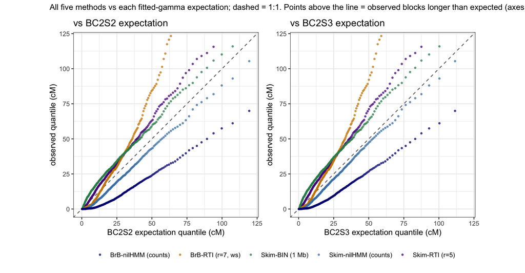

```r
qq_df <- function(x, k, l, label, p = ppoints(200)) tibble(
  theo = qgamma(p, shape = k, rate = l) * 100,             # expectation quantiles (cM)
  samp = as.numeric(quantile(x, p, names = FALSE)), series = label)
cm_of <- function(s) callers$cm[callers$src == s]
LIM <- 120

qq_panel <- function(k, l, xlab, ttl) ggplot(bind_rows(
    qq_df(cm_of("Skim-RTI (r=5)"),       k, l, "Skim-RTI (r=5)"),
    qq_df(cm_of("BrB-RTI (r=7, ws)"),    k, l, "BrB-RTI (r=7, ws)"),
    qq_df(cm_of("Skim-BIN (1 Mb)"),      k, l, "Skim-BIN (1 Mb)"),
    qq_df(cm_of("Skim-nilHMM (counts)"), k, l, "Skim-nilHMM (counts)"),
    qq_df(cm_of("BrB-nilHMM (counts)"),  k, l, "BrB-nilHMM (counts)")),
    aes(theo, samp, colour = series)) +
  geom_abline(slope = 1, intercept = 0, linetype = "dashed", colour = "grey40") +
  geom_point(size = 0.8, alpha = 0.7) +
  scale_colour_manual(values = c("Skim-RTI (r=5)" = "purple4", "BrB-RTI (r=7, ws)" = "orange3",
                                 "Skim-BIN (1 Mb)" = "seagreen4", "Skim-nilHMM (counts)" = "steelblue",
                                 "BrB-nilHMM (counts)" = "navy"), name = NULL) +
  coord_equal(xlim = c(0, LIM), ylim = c(0, LIM)) +
  labs(x = xlab, y = "observed quantile (cM)", title = ttl)

p_qq1 <- qq_panel(f2["shape"], f2["rate"], "BC2S2 expectation quantile (cM)", "vs BC2S2 expectation")
p_qq2 <- qq_panel(f3["shape"], f3["rate"], "BC2S3 expectation quantile (cM)", "vs BC2S3 expectation")

(p_qq1 | p_qq2) + plot_layout(guides = "collect") +
  plot_annotation(subtitle = "All five methods vs each fitted-gamma expectation; dashed = 1:1. Points above the line = observed blocks longer than expected (axes capped at 120 cM).") &
  theme(legend.position = "bottom")
```

## BRB-seq is a different generation (BC2S3 or later)

The skim genotypes are BC2S2 (a bulk of 6 S3 sibs). The **BRB-seq** samples are not: each is a **single plant** grown from the line at **BC2S3 or later** — one realization of an advanced generation, not the S2 parent. Two consequences:

1. **Lower expected heterozygosity** than skim — HET ≤ BC2S3’s 0.031 (and lower for S4+), vs skim’s BC2S2 0.0625.
2. **Built-in skim↔︎BRB discordance, independent of caller quality.** At a locus heterozygous in the S2 parent, the bulked skim reads HET, but the single BRB plant has *resolved* it to ¼ homozygous REF (donor **lost**), ½ HET, ¼ homozygous ALT. So ~half of skim’s HET regions are not expected to read HET on BRB — a structural difference from generation + bulk-vs-single sampling, before any RNA-seq noise.

But the BRB calls **cannot pin the generation**, because RNA-seq genotyping artifacts dominate the composition:

Two callers on the **same BRB reads** make this explicit — **BrB-RTI** (r=7) and **BrB-nilHMM** (count HMM, BC2S3 freqs):

```r
het_sf <- function(seg, lab) seg %>% mutate(len = end_bp - start_bp) %>% group_by(name) %>%
  summarise(HET = sum(len[state == 1]) / sum(len),
            ALT = sum(len[state == 2]) / sum(len), .groups = "drop") %>%
  mutate(dosage = HET/2 + ALT, caller = lab)
brb_sf    <- het_sf(brb,    "BrB-RTI (r=7)")
brbnil_sf <- het_sf(brbnil, "BrB-nilHMM (counts)")
for (d in list(brb_sf, brbnil_sf))
  cat(sprintf("%-20s (n=%d): HET median %.3f mean %.3f | %2.0f%% HET=0 | HET p90 %.2f | HET>0.20 %.1f%% | dosage median %.3f\n",
      d$caller[1], nrow(d), median(d$HET), mean(d$HET), 100*mean(d$HET == 0),
      quantile(d$HET, 0.9), 100*mean(d$HET > 0.20), median(d$dosage)))
```

```
BrB-RTI (r=7)        (n=379): HET median 0.000 mean 0.099 | 61% HET=0 | HET p90 0.48 | HET>0.20 14.0% | dosage median 0.094
BrB-nilHMM (counts)  (n=341): HET median 0.032 mean 0.041 |  2% HET=0 | HET p90 0.09 | HET>0.20 0.9% | dosage median 0.017
```

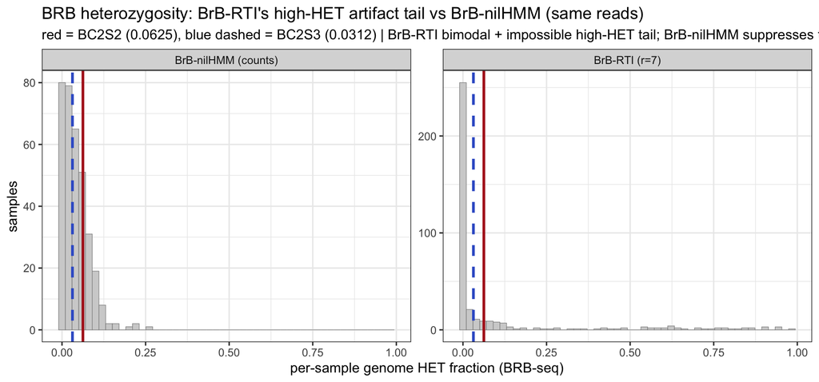

```r
ggplot(bind_rows(brb_sf, brbnil_sf), aes(HET)) +
  geom_histogram(bins = 50, fill = "grey82", colour = "grey55", linewidth = 0.2) +
  geom_vline(xintercept = exp_bc2s2$HET, colour = "firebrick", linewidth = 1) +
  geom_vline(xintercept = exp_bc2s3$HET, colour = "royalblue3", linewidth = 1, linetype = "dashed") +
  facet_wrap(~ caller, scales = "free_y") +
  labs(x = "per-sample genome HET fraction (BRB-seq)", y = "samples",
       title = "BRB heterozygosity: BrB-RTI's high-HET artifact tail vs BrB-nilHMM (same reads)",
       subtitle = "red = BC2S2 (0.0625), blue dashed = BC2S3 (0.0312) | BrB-RTI bimodal + impossible high-HET tail; BrB-nilHMM suppresses the tail")
```

> **⚠ BrB-nilHMM trims the tail by being conservative, not by clean noise/signal separation.** On BRB it **under-calls donor** (genome fraction ~0.04 vs BrB-RTI’s ~0.17 / BC2S3’s ~0.14) and **collapses ALT → HET** (ALT ≈ 0): BRB donor signal reads at alt-fraction ~0.5 (reference-mapping bias / het), which the *fixed* emission mean θ_ALT=0.99 cannot represent, so donor-hom lands on the HET state (RTIGER’s EM-fit emissions recover ALT). So its HET here is a depressed, ALT-merged-in HET, not a generation read-out. Read its donor **footprint**, not its rates. Full diagnosis: `agent/nilhmm/BRB_run_findings.md`.

So BRB is consistent with **BC2S3 or later**, but the generation is not identifiable from either BRB caller the way it is for skim — BrB-RTI’s composition is swamped by RNA artifacts, and BrB-nilHMM’s is dominated by its conservative prior + the ALT collapse.

**Implications for the cross-platform comparison.**

- The two platforms need **platform-specific generation references**: skim → **BC2S2**, BRB → **BC2S3+**. A single shared $p_0$ / Null (as in `skim_brbseq_skimbin.html`) is wrong for one of them.
- **Part of the skim↔︎BRB discordance is structural** (generation + bulk-vs-single sampling, point 2), not caller error — relevant when reading the cross-platform confusion / Jaccard.
- For **fragment size**, BRB over-merges (QQ-plots above), so its blocks run long vs *both* generations’ expectations — the one-meiosis difference is not resolvable from BRB block size.

## Verdict

Both independent tests point to **BC2S2**, consistent with the sampling (6 bulked S3 sibs per S2 ear → the bulk reflects the S2 parent):

- **Heterozygosity** is the decisive, high-contrast test (2× difference between generations): observed HET ≈ 0.076 lands on **BC2S2 (0.0625)**, not BC2S3 (0.0312).
- **Fragment size** is the cleaner, selection-independent test: **BC2S2 fits better** (KS 0.09 vs 0.117 in cM; 0.09 vs 0.114 in Mb), though the one-meiosis effect is small so its discriminating power is limited, and observed blocks still exceed both generations (residual over-length — recombination suppression in teosinte introgressions; see `fragment_size_cm_validation.html`).

**Implication.** For these bulked skim samples the **BC2S2** generation is the correct reference — for the single-locus $p_0$, the introgression-size Null, and the RTIGER rigidity (`r`) calibration target — superseding BC2S3. **BRB-seq, however, is a *different* generation (BC2S3+; see above) and needs its own reference** — the two platforms must not share one.

**Caveats.** The conclusion is robust to two real but separate effects, neither of which changes the generation call: directional **selection against donor** (dosage 0.072 < 0.125) and **overdominance / het-biased retention** (HET:ALT far above the neutral ratio). And the cM conversion of observed blocks leans on conserved marker order relative to the consensus map.